# Analysis of fragmented river systems

2026-02-25

## What we will cover in this presentation

- Why fragmentation is important for riverine metacommunities (alpha and beta diversity).
- Example of application of `riverconn` indices to fish metacommunities in the Ebro basin.
- Generalized linear models for alpha diversity.
- Mantel test and multilinear regression for beta diversity.
- Generalized linear models for the local contribution to beta diversity (LCBD).

## Fragmentation and metacommunities

- Metacommunity: a set of local communities linked by dispersal.
- Local communities are influenced by both local environmental conditions and regional dispersal processes.
- Mass effect (ME) archetype: ‘everything is everywhere’.
- Species sorting (SS) archetype: high effect of local environment (filter).
- Dispersal (connectivity) strength regulates between ME and SS.

## Fragmentation and metacommunities

- In a landscape, central sites are more connected and peripherical sites are more isolated.
- We expect effect of centrality/isolation on alpha and beta diversity.
- River network have per se strong spatial structure.
- dams affect this spatial structure.
- `riverconn` indices can help quantifying this ‘new’ spatial structure.

## Which packages we will use

- `dplyr` for data manipulation: helps building pipelines for easy-to-read data manipulation (loaded with the `tidyverse`).
- `ggplot2` for data visualization: a bit painful, but easily integrates `sf` and `terra` objects for plotting (loaded with the `tidyverse`).
- `vegan` for ecological analyses: provides functions for calculating diversity indices and performing Mantel tests.
- `MASS` for the negative binomial GLM.
- `adespatial` for calculating beta diversity.
- `ecodist` for the Mantel test with multiple predictors.
- `betareg` and `StepBeta` for Generalized Linear Models with beta link function.

## Which packages we will use

```r
library(tidyverse)
library(sf)
library(viridis)
library(igraph)
library(riverconn)
library(vegan)
library(MASS)
library(adespatial)
library(ecodist)
library(betareg)
library(StepBeta)
```

## The Ebro case study: input data

## The Ebro case study: input data

We use fish metacommunities data collected in the Ebro. The data were already processed. First we read all the input data, then we check them.

```r
species_mat_pa  <- read.table("data/metacomm_data/ebro_species_mat_pa.txt")

env_mat <- read.table("data/metacomm_data/ebro_env_mat.txt") %>%
  dplyr::mutate( across( where(is.character), factor))

frag_mat <- read.table("data/metacomm_data/ebro_frag_mat.txt")

centr_mat <- read.table("data/metacomm_data/ebro_centr_mat.txt")

dist_mat <- readRDS("data/metacomm_data/dist_mat_ebro.RDS")
dist_mat <- dist_mat[rownames(species_mat_pa), rownames(species_mat_pa)]
```

## The Ebro case study: input data

We check the species-sites matrix (`species_mat_pa`). There’s not many species in the Ebro, and most of the sites have few species.

```r
nrow(species_mat_pa)
```

```
## [1] 596
```

```r
ncol(species_mat_pa)
```

```
## [1] 13
```

## The Ebro case study: input data

We check the species-sites matrix (`species_mat_pa`). There’s not many species in the Ebro, and most of the sites have few species.

```r
names(species_mat_pa)
```

```
##  [1] "Salmo.trutta"            "Phoxinus.phoxinus"
##  [3] "Parachondrostoma.miegii" "Luciobarbus.graellsii"
##  [5] "Salaria.fluviatilis"     "Cobitis.calderoni"
##  [7] "Barbus.haasi"            "Gobio.lozanoi"
##  [9] "Phoxinus.bigerri"        "Achondrostoma.arcasii"
## [11] "Squalius.laietanus"      "Anguilla.anguilla"
## [13] "Cobitis.paludica"
```

```r
rowSums(species_mat_pa) %>% summary()
```

```
##    Min. 1st Qu.  Median    Mean 3rd Qu.    Max.
##   1.000   2.000   3.000   3.111   4.000   9.000
```

## The Ebro case study: input data

We read the sampling points shapefile and plot the species richness.

```r
richness <- rowSums(species_mat_pa) %>%
  data.frame(Site_ID = names(.), richness = .)

sampling_points <- st_read("data/metacomm_data/fish_Ebro_points.shp", quiet = TRUE) %>%
  dplyr::filter(Site_ID %in% rownames(species_mat_pa) ) %>%
  left_join(richness, by = "Site_ID")

river_shapefile <- st_read("data/river_graph/river_net_simplified.shp", quiet = TRUE)
```

## The Ebro case study: input data

We read the sampling points shapefile and plot the species richness.

```r
plot <- ggplot() +  theme_minimal() +
  geom_sf(data = river_shapefile, color = "gray50", size = 0.2) +
  geom_sf(data = sampling_points, aes(color = richness), alpha = 0.5) +
  scale_color_viridis(name = "Species richness") +
  theme(legend.position = "right")
```

## The Ebro case study: input data

We read the sampling points shapefile and plot the species richness.

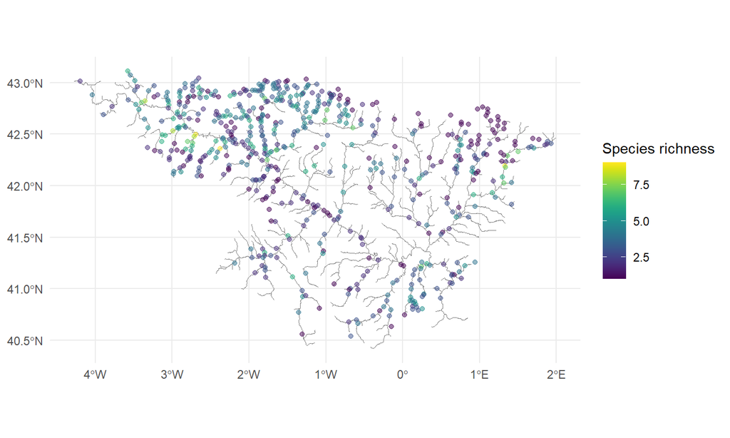

## The Ebro case study: input data

We check the environmental data matrix (`env_mat`). We have 11 covariates.

```r
nrow(env_mat)
```

```
## [1] 596
```

```r
ncol(env_mat)
```

```
## [1] 11
```

```r
names(env_mat)
```

```
##  [1] "Geology" "Gem_typ" "LUses"   "order"   "elev"    "Cond_Gl" "Dischrg"
##  [8] "Mn_Ar_T" "AGR"     "FR"      "UR"
```

## The Ebro case study: input data

From the fragmentation matrix (`frag_mat`) we consider the DCI values calculated with: uniform habitat weight, symmetric dispersal (`param = c(0.3, 0.6, 0.9)`), and `pass_u = pass_d = 0.5`

```r
frag_mat %>%
  dplyr::select(index_us0.3,index_us0.6,index_us0.9 ) %>%
  summary()
```

```
##   index_us0.3         index_us0.6         index_us0.9
##  Min.   :0.0002350   Min.   :0.0002379   Min.   :0.0002391
##  1st Qu.:0.0007128   1st Qu.:0.0019773   1st Qu.:0.0063952
##  Median :0.0010638   Median :0.0030773   Median :0.0118532
##  Mean   :0.0013462   Mean   :0.0034822   Mean   :0.0134688
##  3rd Qu.:0.0017339   3rd Qu.:0.0044476   3rd Qu.:0.0202025
##  Max.   :0.0055943   Max.   :0.0142449   Max.   :0.0372816
```

## The Ebro case study: input data

We consider also two classic network centrality metrics: betweenness centrality and out-closeness centrality.

```r
centr_mat %>%
  dplyr::select(BCdir, CCout) %>%
  summary()
```

```
##      BCdir            CCout
##  Min.   : 0.000   Min.   :0.0002441
##  1st Qu.: 5.820   1st Qu.:0.0002476
##  Median : 7.273   Median :0.0002490
##  Mean   : 6.732   Mean   :0.0002488
##  3rd Qu.: 8.654   3rd Qu.:0.0002501
##  Max.   :11.677   Max.   :0.0002531
```

## The Ebro case study: input data

Finally, we also check the distance matrix (distances in meters).

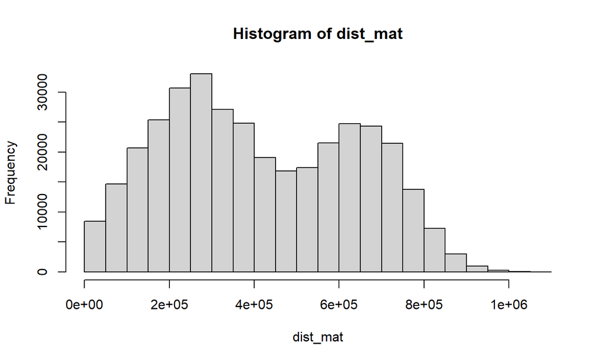

```r
hist(dist_mat)
```

## The Ebro case study: input data

We have all the data we need. We put all the predictors in a single data.frame. We logtransform fragmentation variables. We logit-transform land use variables. Finally, we scale all the variables. We drop a couple of variables that are highli correlated.

```r
pred_mat_lm_full <- cbind(
  env_mat %>% dplyr::select(elev, Dischrg) %>%  rename(size = Dischrg) %>%
    dplyr::mutate(size = (size)^0.25),
  env_mat %>% dplyr::select(AGR, UR, FR) %>% car::logit(),
  frag_mat %>% dplyr::select(index_us0.3, index_us0.6, index_us0.9) %>%
    dplyr::mutate(index_us0.3 = log10(index_us0.3),
                  index_us0.6 = log10(index_us0.6),
                  index_us0.9 = log10(index_us0.9)) %>%
    rename_all(~stringr::str_replace(.,"index_","")),
  centr_mat %>% dplyr::select(BCdir, CCout) ) %>%
  mutate_if(is.numeric, ~(scale(.) %>% as.vector))
cor_mat <- pred_mat_lm_full %>%  cor(method = "spearman")
pred_mat_lm <- pred_mat_lm_full %>% dplyr::select(-us0.6, -FR)
```

## The Ebro case study: input data

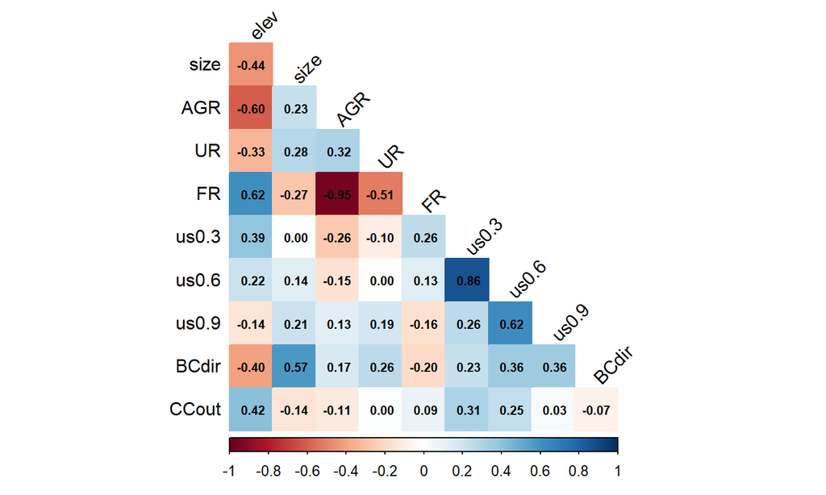

```r
corrplot::corrplot(cor_mat, type = "lower", method = "color", tl.col = "black", tl.srt = 45,
    addCoef.col = "black", number.cex = 0.7, diag = FALSE)
```

## The Ebro case study: alpha diversity

## The Ebro case study: alpha diversity

We want to analyze the drivers of alpha diversity. We use species richness and we employ a Generalized Linear Model with a negative binomial link function. We use a forward selection to select a parsimonious model.

```r
rich <- rowSums(species_mat_pa)
```

## The Ebro case study: alpha diversity

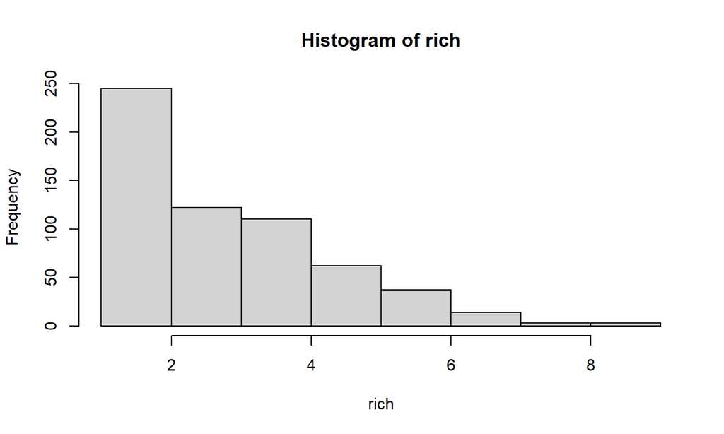

```r
hist(rich)
```

## The Ebro case study: alpha diversity

We want to analyze the drivers of alpha diversity. We use species richness and we employ a Generalized Linear Model with a negative binomial link function. We use a forward selection to select a parsimonious model.

```r
lm_rich <- step(
  object = glm.nb(rich ~ 1, data = pred_mat_lm),
  scope = formula(glm.nb(rich ~ ., data = pred_mat_lm)),
  direction = "forward", trace = 0)
```

## The Ebro case study: alpha diversity

```r
summary(lm_rich)
```

```
##
## Call:
## glm.nb(formula = rich ~ elev + CCout + us0.3 + size, data = pred_mat_lm,
##     init.theta = 53607.91876, link = log)
##
## Coefficients:
##             Estimate Std. Error z value Pr(>|z|)
## (Intercept)  1.11086    0.02384  46.589  < 2e-16 ***
## elev        -0.27077    0.03429  -7.897 2.85e-15 ***
## CCout        0.12519    0.02596   4.823 1.41e-06 ***
## us0.3        0.06796    0.02690   2.526   0.0115 *
## size        -0.05075    0.02597  -1.954   0.0507 .
## ---
## Signif. codes:  0 '***' 0.001 '**' 0.01 '*' 0.05 '.' 0.1 ' ' 1
##
## (Dispersion parameter for Negative Binomial(53607.92) family taken to be 1)
##
##     Null deviance: 547.54  on 595  degrees of freedom
## Residual deviance: 468.05  on 591  degrees of freedom
## AIC: 2197.6
##
## Number of Fisher Scoring iterations: 1
##
##
##               Theta:  53608
##           Std. Err.:  349251
## Warning while fitting theta: iteration limit reached
##
##  2 x log-likelihood:  -2185.599
```

## The Ebro case study: alpha diversity

We see that fragmentation has some effect, but not the way we intend it.

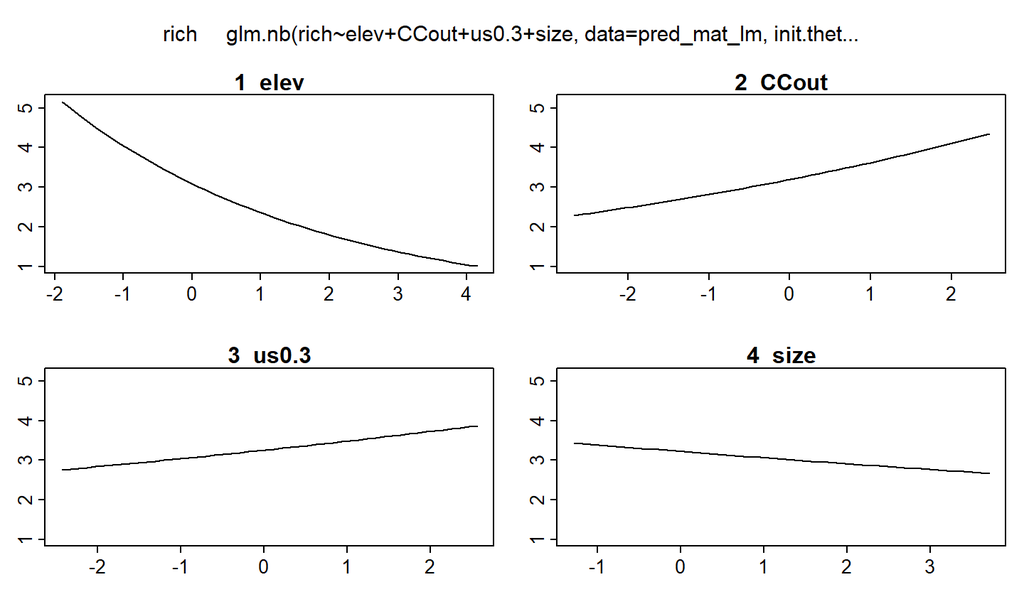

## The Ebro case study: beta diversity

## The Ebro case study: beta diversity

Next we want to analyze what are the drivers of beta diversity. First we calculate the beta diversity matrix with `adespatial::beta.div()` function. We use the Sorensen indices, and we are interested in three components of the beta diversity: the total beta diversity (D), the richness difference (rich), and the replacement (repl), as they capture different community asssembly processes.

```r
beta <- beta.div.comp(species_mat_pa, coef = "S")
names(beta)
```

[output not shown]

## The Ebro case study: beta diversity

We want to use a Mantel test (`ecodist::mantel()`) to check the influence of fragmentation on beta diversity. First we calculate distances between predictors. We also retain the lower triangle of the distance matrix for later use.

```r
dist_data <- cbind(
  "AGR" = ecodist::distance(env_mat$AGR  %>% car::logit() %>% scale %>% as.vector),
  "UR" = ecodist::distance(env_mat$UR  %>% car::logit() %>% scale %>% as.vector),
  "us0.3" = ecodist::distance(frag_mat$index_us0.3 %>% scale %>% as.vector),
  "us0.6" = ecodist::distance(frag_mat$index_us0.6 %>% scale %>% as.vector),
  "us0.9" = ecodist::distance(frag_mat$index_us0.9 %>% scale %>% as.vector),
  "elev" = ecodist::distance(env_mat$elev %>% scale %>% as.vector),
  "size" = ecodist::distance(env_mat$Dischrg ^ 0.25 %>% scale %>% as.vector),
  "bc" = ecodist::distance(centr_mat$BCdir %>% scale %>% as.vector),
  "cc" = ecodist::distance(centr_mat$CCout %>% scale %>% as.vector)
) %>% as.data.frame()

dist_mat_v <- dist_mat[lower.tri(dist_mat)]
```

## The Ebro case study: beta diversity

We use the Mantel test to check the influence of fragmentation on beta diversity. We partial out the effect of distance. The tests are marginally significant.

```r
ecodist::mantel(as.vector(beta$D) ~ dist_data$us0.9 + dist_mat_v, mrank = TRUE)
```

```
##    mantelr      pval1      pval2      pval3  llim.2.5% ulim.97.5%
## 0.01979851 0.04800000 0.95300000 0.07700000 0.01370841 0.02659928
```

```r
ecodist::mantel(as.vector(beta$D) ~ dist_data$us0.3 + dist_mat_v, mrank = TRUE)
```

```
##    mantelr      pval1      pval2      pval3  llim.2.5% ulim.97.5%
## 0.03131460 0.03300000 0.96800000 0.05300000 0.01877245 0.04395586
```

## The Ebro case study: beta diversity

Instead we check the effect of elevation and size, and they are both highly significant.

```r
ecodist::mantel(as.vector(beta$D) ~ dist_data$elev + dist_mat_v, mrank = TRUE)
```

```
##    mantelr      pval1      pval2      pval3  llim.2.5% ulim.97.5%
##  0.3316262  0.0010000  1.0000000  0.0010000  0.3201245  0.3459023
```

```r
ecodist::mantel(as.vector(beta$D) ~ dist_data$size + dist_mat_v, mrank = TRUE)
```

```
##    mantelr      pval1      pval2      pval3  llim.2.5% ulim.97.5%
## 0.11300029 0.00100000 1.00000000 0.00100000 0.09859098 0.12542166
```

## The Ebro case study: beta diversity

We check the effect of fragmentation on the replacement component.

```r
ecodist::mantel(as.vector(beta$repl) ~ dist_data$us0.9 + dist_mat_v, mrank = TRUE)
```

```
##      mantelr        pval1        pval2        pval3    llim.2.5%   ulim.97.5%
##  0.005452647  0.305000000  0.696000000  0.617000000 -0.002620981  0.012728133
```

```r
ecodist::mantel(as.vector(beta$repl) ~ dist_data$us0.3 + dist_mat_v, mrank = TRUE)
```

```
##      mantelr        pval1        pval2        pval3    llim.2.5%   ulim.97.5%
## -0.003790225  0.608000000  0.393000000  0.812000000 -0.014065220  0.007746220
```

## The Ebro case study: beta diversity

We check the effect of fragmentation on the richness difference component.

```r
ecodist::mantel(as.vector(beta$rich) ~ dist_data$us0.9 + dist_mat_v, mrank = TRUE)
```

```
##    mantelr      pval1      pval2      pval3  llim.2.5% ulim.97.5%
## 0.01799911 0.02400000 0.97700000 0.03900000 0.01115734 0.02405441
```

```r
ecodist::mantel(as.vector(beta$rich) ~ dist_data$us0.3 + dist_mat_v, mrank = TRUE)
```

```
##    mantelr      pval1      pval2      pval3  llim.2.5% ulim.97.5%
## 0.03291639 0.00400000 0.99700000 0.00500000 0.02252730 0.04283849
```

## The Ebro case study: beta diversity

To facilitate the comparison we can use the multilinear regression on the distance matrix, that allows for multiple predictors. No significant effect of fragmentation.

```r
mrm_model <- MRM(formula = as.vector(beta$D) ~., data = dist_data, mrank = TRUE)
mrm_model$coef
```

```
##       as.vector(beta$D)  pval
## Int        3.046073e+04 1.000
## AGR        8.234396e-02 0.001
## UR         5.466730e-02 0.003
## us0.3     -2.237881e-02 0.178
## us0.6      1.438261e-02 0.368
## us0.9     -1.023377e-02 0.298
## elev       2.950599e-01 0.001
## size       3.522945e-02 0.021
## bc         8.339824e-02 0.001
## cc         1.239458e-01 0.001
```

## The Ebro case study: beta diversity

To facilitate the comparison we can use the multilinear regression on the distance matrix, that allows for multiple predictors.

```r
mrm_model$r.squared
```

```
##        R2      pval
## 0.1531743 0.0010000
```

```r
mrm_model$F.test
```

```
##        F   F.pval
## 3563.346    0.001
```

## The Ebro case study: beta diversity

We fit a MRM model to the replacement component. Marginally significant effect of fragmentation.

```r
mrm_model <- MRM(formula = as.vector(beta$repl) ~., data = dist_data, mrank = TRUE)
mrm_model$coef
```

```
##       as.vector(beta$repl)  pval
## Int           3.775090e+04 1.000
## AGR           7.335994e-02 0.001
## UR            8.538736e-02 0.001
## us0.3        -4.922198e-03 0.764
## us0.6        -3.153963e-02 0.034
## us0.9        -1.558248e-02 0.093
## elev          1.713842e-01 0.001
## size          5.543062e-02 0.001
## bc            8.266809e-02 0.001
## cc            1.579984e-01 0.001
```

## The Ebro case study: beta diversity

We fit a MRM model to the replacement component. Significant effect of fragmentation.

```r
mrm_model$r.squared
```

```
##        R2      pval
## 0.1008749 0.0010000
```

```r
mrm_model$F.test
```

```
##        F   F.pval
## 2210.188    0.001
```

## The Ebro case study: beta diversity

We fit a MRM model to the richness difference component. Significant effect of fragmentation.

```r
mrm_model <- MRM(formula = as.vector(beta$rich) ~., data = dist_data, mrank = TRUE)
mrm_model$coef
```

```
##       as.vector(beta$rich)  pval
## Int           7.788446e+04 1.000
## AGR           1.412649e-02 0.134
## UR           -2.481665e-02 0.107
## us0.3        -2.159695e-02 0.098
## us0.6         4.938778e-02 0.002
## us0.9         8.226439e-03 0.309
## elev          1.371082e-01 0.001
## size         -1.672386e-02 0.173
## bc            5.803352e-03 0.622
## cc           -3.002163e-02 0.005
```

## The Ebro case study: beta diversity

```r
mrm_model$r.squared
```

```
##         R2       pval
## 0.02312203 0.00100000
```

```r
mrm_model$F.test
```

```
##        F   F.pval
## 466.2854   0.0010
```

## The Ebro case study: Local Contribution to Beta Diversity (LCBD)

## The Ebro case study: LCBD

Finally, we analyze LCBD, that is the contribution of each site to the total beta diversity. We check if LCBD is related to fragmentation. We first calculate LCBDs.

```r
LCBD_df <- data.frame(
  "site" = rownames(species_mat_pa),
  "LCBD_repl" = LCBD.comp(beta[[1]] ^ 0.5 )[[2]],
  "LCBD_rich" = LCBD.comp(beta[[2]] ^ 0.5 )[[2]],
  "LCBD_D" = LCBD.comp(beta[[3]] ^ 0.5 )[[2]]  ) %>%
  column_to_rownames("site") %>%
  mutate(LCBD_repl = ifelse(LCBD_repl <0, abs(LCBD_repl), LCBD_repl))
```

## The Ebro case study: LCBD

We fit a Generalized Linear Model with a beta link function.

```r
beta <- LCBD_df$LCBD_D
start <- betareg::betareg(beta ~ ., data = pred_mat_lm)
breg <- StepBeta::StepBeta(start)
breg$pseudo.r.squared
```

## The Ebro case study: LCBD

```
##
## Call:
## "betareg(formula =  beta ~ CCout + size + BCdir + us0.3 + elev + AGR data = pred_mat_lm )"
##
## Quantile residuals:
##     Min      1Q  Median      3Q     Max
## -2.7636 -0.6411 -0.0084  0.5891  2.9238
##
## Coefficients (mean model with logit link):
##              Estimate Std. Error  z value Pr(>|z|)
## (Intercept) -6.391211   0.007889 -810.124  < 2e-16 ***
## CCout       -0.053288   0.008593   -6.201 5.60e-10 ***
## size         0.043436   0.009813    4.427 9.58e-06 ***
## BCdir       -0.024190   0.010221   -2.367  0.01795 *
## us0.3       -0.020264   0.009511   -2.131  0.03313 *
## elev         0.032560   0.011531    2.824  0.00475 **
## AGR          0.019702   0.009567    2.059  0.03946 *
## ---
## Signif. codes:  0 '***' 0.001 '**' 0.01 '*' 0.05 '.' 0.1 ' ' 1
##
## Type of estimator: ML (maximum likelihood)
## Log-likelihood:  3955 on 8 Df
## Pseudo R-squared: 0.1269
## Number of iterations: 58 (BFGS) + 15 (Fisher scoring)
```

## The Ebro case study: LCBD

We fit a Generalized Linear Model with a beta link function. We fit the replacement LCBDs.

```r
beta <- LCBD_df$LCBD_repl
start <- betareg::betareg(beta ~ ., data = pred_mat_lm)
breg <- StepBeta::StepBeta(start)
breg$pseudo.r.squared
```

## The Ebro case study: LCBD

```
##
## Call:
## "betareg(formula =  beta ~ CCout + us0.3 + size + BCdir + AGR + UR data = pred_mat_lm )"
##
## Quantile residuals:
##     Min      1Q  Median      3Q     Max
## -4.3733 -0.5735  0.0766  0.7311  2.1560
##
## Coefficients (mean model with logit link):
##             Estimate Std. Error  z value Pr(>|z|)
## (Intercept) -6.41498    0.02331 -275.225  < 2e-16 ***
## CCout       -0.16621    0.02239   -7.422 1.15e-13 ***
## us0.3       -0.07096    0.02431   -2.919 0.003516 **
## size         0.10854    0.02535    4.282 1.85e-05 ***
## BCdir       -0.09220    0.02625   -3.512 0.000444 ***
## AGR          0.06314    0.02259    2.795 0.005192 **
## UR           0.04892    0.02110    2.319 0.020400 *
## ---
## Signif. codes:  0 '***' 0.001 '**' 0.01 '*' 0.05 '.' 0.1 ' ' 1
##
## Type of estimator: ML (maximum likelihood)
## Log-likelihood:  3392 on 8 Df
## Pseudo R-squared: 0.1584
## Number of iterations: 77 (BFGS) + 6 (Fisher scoring)
```

## The Ebro case study: LCBD

We fit a Generalized Linear Model with a beta link function. We fit the richness difference LCBDs.

```r
beta <- LCBD_df$LCBD_rich
start <- betareg::betareg(beta ~ ., data = pred_mat_lm)
breg <- StepBeta::StepBeta(start)
breg$pseudo.r.squared
```

## The Ebro case study: LCBD

```
##
## Call:
## "betareg(formula =  beta ~ elev + us0.9 data = pred_mat_lm )"
##
## Quantile residuals:
##     Min      1Q  Median      3Q     Max
## -1.7909 -0.7872 -0.3646  0.9584  2.9450
##
## Coefficients (mean model with logit link):
##              Estimate Std. Error  z value Pr(>|z|)
## (Intercept) -6.390603   0.010445 -611.850  < 2e-16 ***
## elev         0.062437   0.009948    6.277 3.46e-10 ***
## us0.9        0.017566   0.010415    1.687   0.0917 .
## ---
## Signif. codes:  0 '***' 0.001 '**' 0.01 '*' 0.05 '.' 0.1 ' ' 1
##
## Type of estimator: ML (maximum likelihood)
## Log-likelihood:  3793 on 4 Df
## Pseudo R-squared: 0.05786
## Number of iterations: 5000 (BFGS) + 9 (Fisher scoring)
```